# Notebook 02: Creating the Model Matrix

```r
library(tidyverse)
library(forcats)
library(ggrepel)
library(smodels)

theme_set(theme_minimal())
options(dplyr.summarise.inform = FALSE)
options(width = 77L)
```

## Predicting Bike Usage

Today, we will look at a data set of bike sharing usage in Washington, DC. Our task is to predict how many bikes are rented each day. As we saw in the previous set of notes, it will be useful to split the data set into training and validation sets. We will do this right as the data is read into R.

```r
set.seed(1)

bikes <- read_csv("data/bikes.csv") %>%
  mutate(train_id = if_else(runif(n()) < 0.6, "train", "valid"))
bikes
```

```
## # A tibble: 731 x 9
##    count season year  workingday weather  temp humidity windspeed train_id
##    <dbl> <chr>  <chr>      <dbl> <chr>   <dbl>    <dbl>     <dbl> <chr>
##  1   985 Winter one            0 Rain     6.72    0.806     17.3  valid
##  2   801 Winter one            0 Rain     7.99    0.696     26.8  valid
##  3  1349 Winter one            1 Dry     -3.04    0.437     26.8  train
##  4  1562 Winter one            1 Dry     -2.8     0.590     17.3  train
##  5  1600 Winter one            1 Dry     -1.02    0.437     20.2  train
##  6  1606 Winter one            1 Dry     -2.51    0.518      9.66 valid
##  7  1510 Winter one            1 Rain    -3.03    0.499     18.2  train
##  8   959 Winter one            0 Rain    -5.11    0.536     28.8  valid
##  9   822 Winter one            0 Dry     -6.87    0.434     39.0  train
## 10  1321 Winter one            1 Dry     -6.05    0.483     24.1  valid
## # … with 721 more rows
```

### Non-linear relationships

The data comes from two different years. There was an overall increase in usage during the second year, so it is useful to start by looking at just the second year (we will see how to incorporate both together in just a moment). Here is a plot that investigates the relationship between the maximum daily temperature (degrees Celsius) and the number of bikes that are rented.

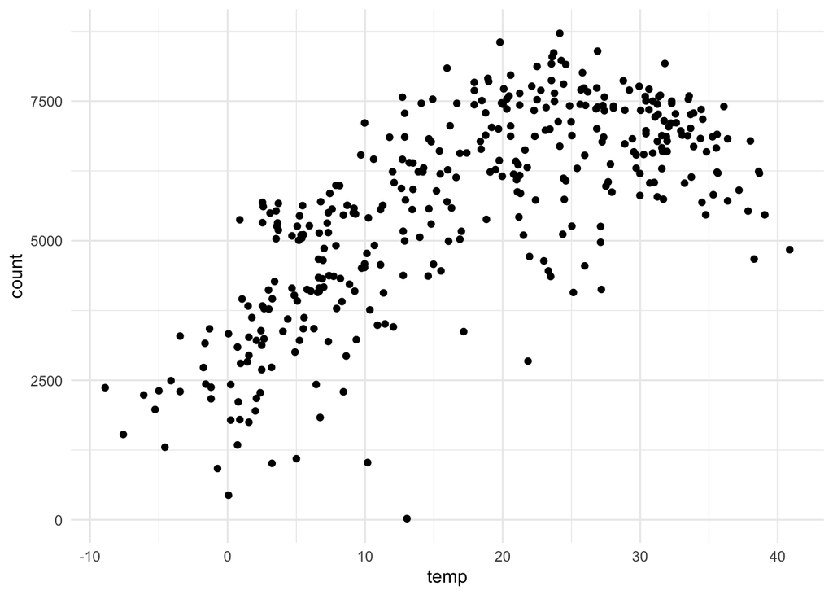

```r
bikes %>%
  filter(year == "two") %>%
  ggplot(aes(temp, count)) +
    geom_point()
```

Generally, people are more willing to rent bikes when the weather is warmer. However, the usage drops a bit when the temperatures are too high. The peak usage visually seems to be right around 20-25°, which is right around the optimal temperature for a bike ride.

We will start by building a linear model between the temperature and the bike usage in year two. Rather than worrying about the RMSE, we will start by just visually inspecting the results.

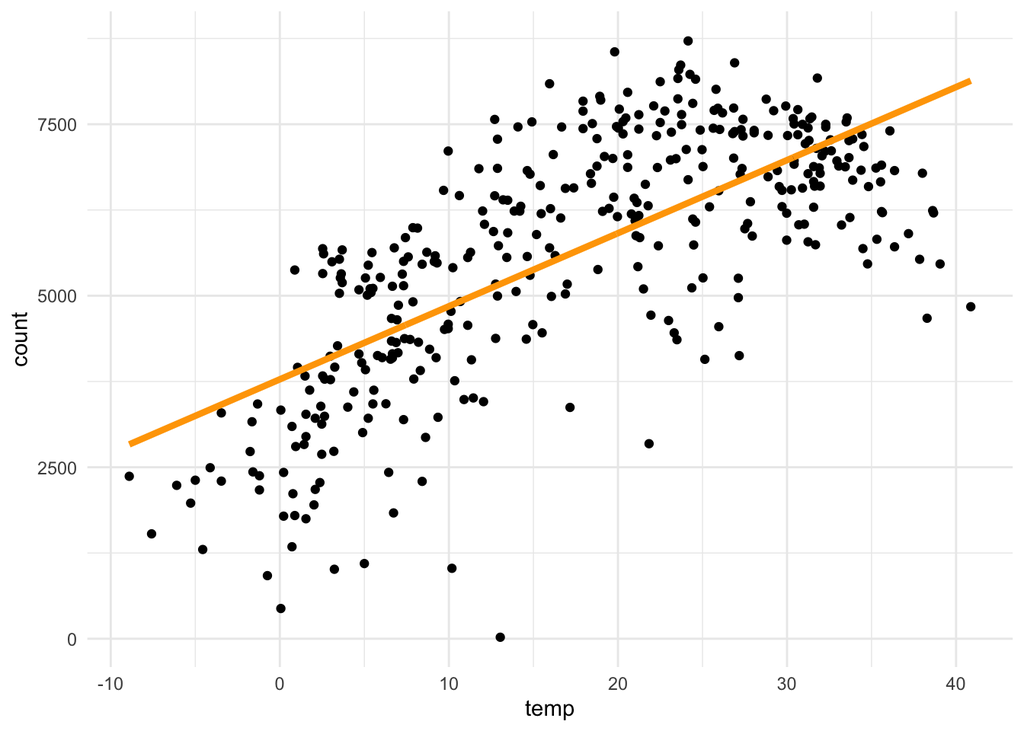

```r
model <- bikes %>%
  filter(year == "two") %>%
  filter(train_id == "train") %>%
  lm(count ~ temp, data = .)

bikes %>%
  filter(year == "two") %>%
  mutate(score_pred = predict(model, newdata = .)) %>%
  ggplot(aes(temp, count)) +
    geom_point() +
    geom_line(aes(y = score_pred), color = "orange", size = 1.5)
```

The best fit line seems to over-predict usage at very low temperatures and very high temperatures. We already noted that the relationship is not a linear one, so it is not surprising that linear regression line fails to match the data for all temperature values.

You might think that we need an entirely different kind of model to deal with this data. After all, we have a non-linear relationship, so how can we use a linear model? It turns out, helpfully, that this is in fact not the case because linear models are only constrained to be linear in the sense that the unknown coefficients must be linearly related to the output. However, we can create additional predictor variables to fit high order relationships. For example, we can fit the following model to predict a quadratic relationship between x and y:

$$Y_i = \alpha + \beta_1 X_{i} + \beta_2 X_{i}^2 + \epsilon_i$$

In other words, we have converted a non-linear model with one variable into a linear model with two variables. Let’s see how this could work in R by creating a temporary variable of the squared temperature:

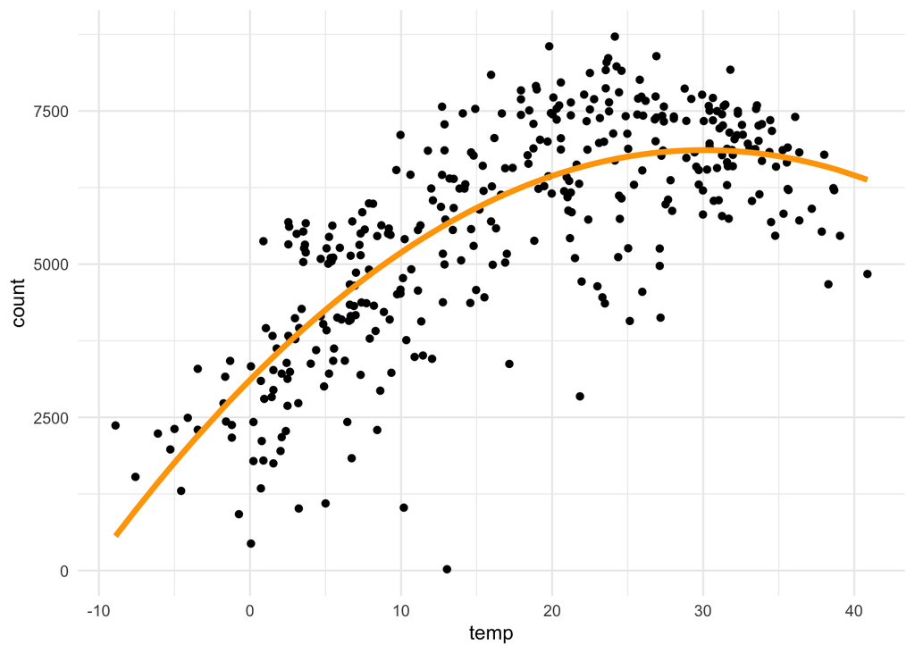

```r
model <- bikes %>%
  filter(year == "two") %>%
  filter(train_id == "train") %>%
  mutate(temp_sq = temp^2) %>%
  lm(count ~ temp + temp_sq, data = .)

bikes %>%
  filter(year == "two") %>%
  mutate(temp_sq = temp^2) %>%
  mutate(score_pred = predict(model, newdata = .)) %>%
  ggplot(aes(temp, count)) +
    geom_point() +
    geom_line(aes(y = score_pred), color = "orange", size = 1.5)
```

Now, the model fits the data much more accurately at the extreme temperature values. An alternative way of fitting the same model without having to worry about manually constructing a new variable of squares is through the `poly()` function. It does all of the work for us; while in theory it produces the same fit as the code above, it does so using a more numerically stable algorithm.

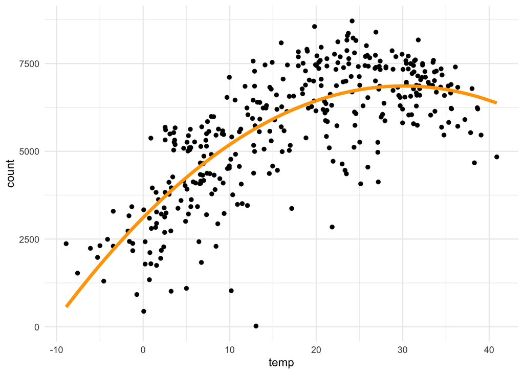

```r
model <- bikes %>%
  filter(year == "two") %>%
  filter(train_id == "train") %>%
  lm(count ~ poly(temp, degree = 2), data = .)

bikes %>%
  filter(year == "two") %>%
  mutate(score_pred = predict(model, newdata = .)) %>%
  ggplot(aes(temp, count)) +
    geom_point() +
    geom_line(aes(y = score_pred), color = "orange", size = 1.5)
```

The `poly` function can be used to fit higher-order interactions by increasing the degree of the polynomial.

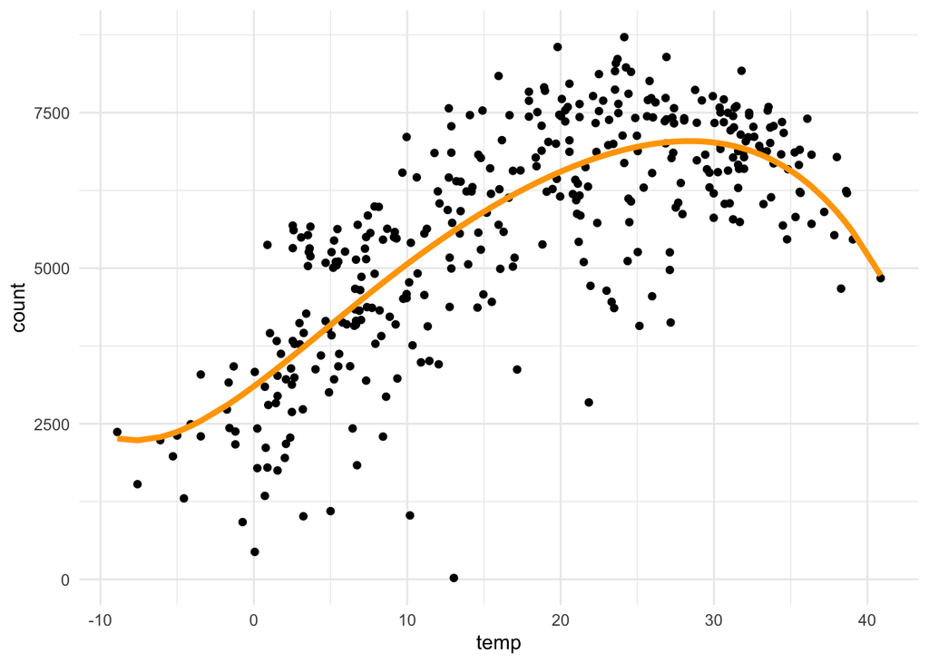

```r
model <- bikes %>%
  filter(year == "two") %>%
  filter(train_id == "train") %>%
  lm(count ~ poly(temp, degree = 5), data = .)

bikes %>%
  filter(year == "two") %>%
  mutate(score_pred = predict(model, newdata = .)) %>%
  ggplot(aes(temp, count)) +
    geom_point() +
    geom_line(aes(y = score_pred), color = "orange", size = 1.5)
```

Here, the fifth-order polynomial does a better job of capturing the extreme tails of the data: a smaller slope for very low temperatures and a sharper one for high temperatures.

### Indicator variables

Now, let’s try to get a handle on the two different years of the data. Drawing the temperature-count relationship with both years shows the large increase in usage from year one to year two.

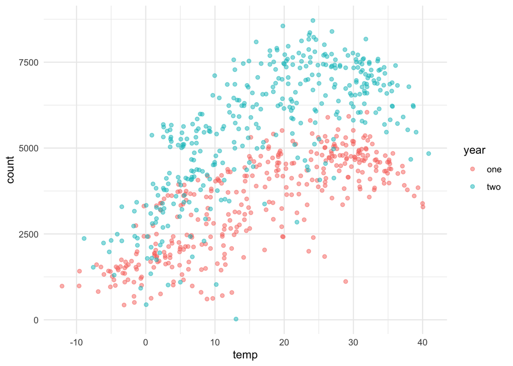

```r
bikes %>%
  ggplot(aes(temp, count)) +
    geom_point(aes(color = year), alpha = 0.5)
```

We can also model this relationship with a linear model by constructing another new variable called an *indicator variable*. This variable takes on only two values: 0 or 1. It is defined to be one in year two and zero otherwise. If we call this variable Z, we can think of our linear model being:

$$Y_i = \alpha + \beta_1 X_{i} + \beta_3 Z_{i} + \epsilon_i$$

Constructing this variable manually, we can create a model in R with the following:

```r
bikes %>%
  mutate(yeartwo = if_else(year == "two", 1, 0)) %>%
  filter(train_id == "train") %>%
  lm(count ~ temp + yeartwo, data = .) %>%
  summary()
```

```
##
## Call:
## lm(formula = count ~ temp + yeartwo, data = .)
##
## Residuals:
##     Min      1Q  Median      3Q     Max
## -5200.2  -558.2   -23.2   807.8  2595.5
##
## Coefficients:
##             Estimate Std. Error t value Pr(>|t|)
## (Intercept) 1900.577    101.607   18.70   <2e-16 ***
## temp          93.410      4.338   21.53   <2e-16 ***
## yeartwo     2103.576    104.092   20.21   <2e-16 ***
## ---
## Signif. codes:  0 '***' 0.001 '**' 0.01 '*' 0.05 '.' 0.1 ' ' 1
##
## Residual standard error: 1093 on 439 degrees of freedom
## Multiple R-squared:  0.6701, Adjusted R-squared:  0.6686
## F-statistic: 445.9 on 2 and 439 DF,  p-value: < 2.2e-16
```

The coefficient for the `yeartwo` variable (2103.58) gives the increase in bikes rented on average between year one and year two after accounting for the temperature variable. As with the polynomial expansion in the previous section, we can let R handle the creation of the indicator variable by just adding the year variable in to the R formula.

```r
bikes %>%
  filter(train_id == "train") %>%
  lm(count ~ temp + year, data = .) %>%
  summary()
```

```
##
## Call:
## lm(formula = count ~ temp + year, data = .)
##
## Residuals:
##     Min      1Q  Median      3Q     Max
## -5200.2  -558.2   -23.2   807.8  2595.5
##
## Coefficients:
##             Estimate Std. Error t value Pr(>|t|)
## (Intercept) 1900.577    101.607   18.70   <2e-16 ***
## temp          93.410      4.338   21.53   <2e-16 ***
## yeartwo     2103.576    104.092   20.21   <2e-16 ***
## ---
## Signif. codes:  0 '***' 0.001 '**' 0.01 '*' 0.05 '.' 0.1 ' ' 1
##
## Residual standard error: 1093 on 439 degrees of freedom
## Multiple R-squared:  0.6701, Adjusted R-squared:  0.6686
## F-statistic: 445.9 on 2 and 439 DF,  p-value: < 2.2e-16
```

Plotting the model now shows that the predictions are given by two parellel lines.

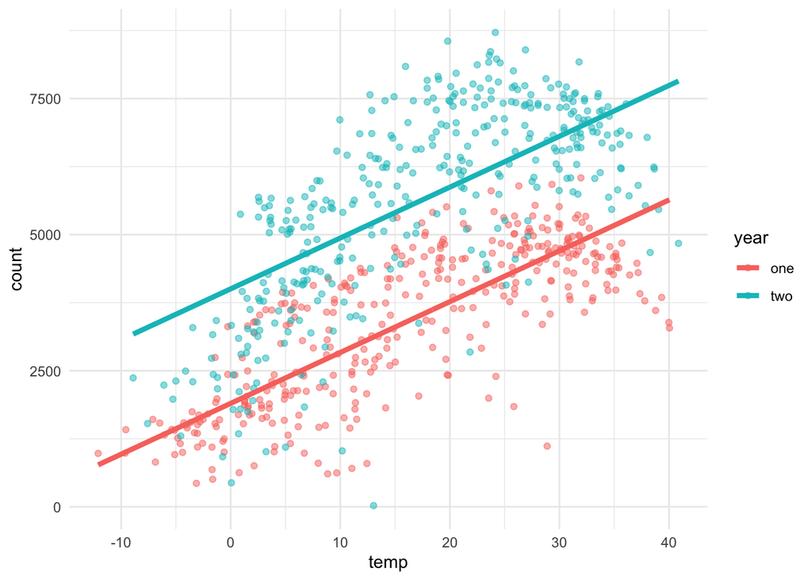

```r
model <- bikes %>%
  filter(train_id == "train") %>%
  lm(count ~ temp + year, data = .)

bikes %>%
  mutate(score_pred = predict(model, newdata = .)) %>%
  ggplot(aes(temp, count)) +
    geom_point(aes(color = year), alpha = 0.5) +
    geom_line(aes(y = score_pred, color = year), size = 1.5)
```

We can, of course, combine this with the polynomial expansion to have two polynomials with different intercepts.

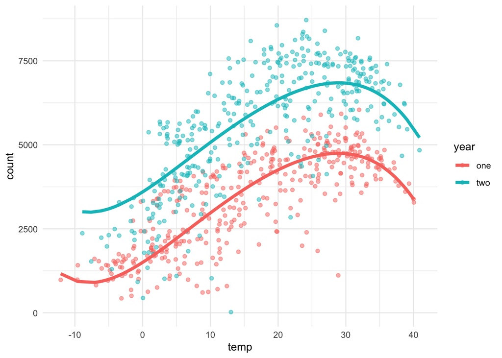

```r
model <- bikes %>%
  filter(train_id == "train") %>%
  lm(count ~ poly(temp, 5) + year, data = .)

bikes %>%
  mutate(score_pred = predict(model, newdata = .)) %>%
  ggplot(aes(temp, count)) +
    geom_point(aes(color = year), alpha = 0.5) +
    geom_line(aes(y = score_pred, color = year), size = 1.5)
```

Sometimes it can even be useful to have different slopes for the two lines. To do this, we multiply the two variables together in the model formula.

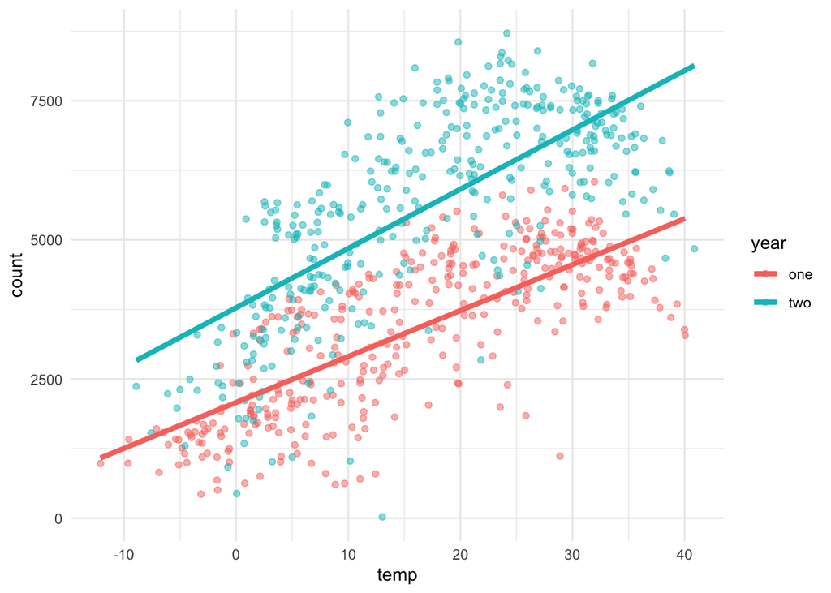

```r
model <- bikes %>%
  filter(train_id == "train") %>%
  lm(count ~ temp * year, data = .)

bikes %>%
  mutate(score_pred = predict(model, newdata = .)) %>%
  ggplot(aes(temp, count)) +
    geom_point(aes(color = year), alpha = 0.5) +
    geom_line(aes(y = score_pred, color = year), size = 1.5)
```

### Indicator variables: Three or more categories

Finally, the approach above works equally well when we have a variable with more than two categories. The R syntax and the geometric interpretation extend as you would expect. For example, if we use the weather variable, which has three categories (Dry, Rain, and Snow) we now have three parallel curves:

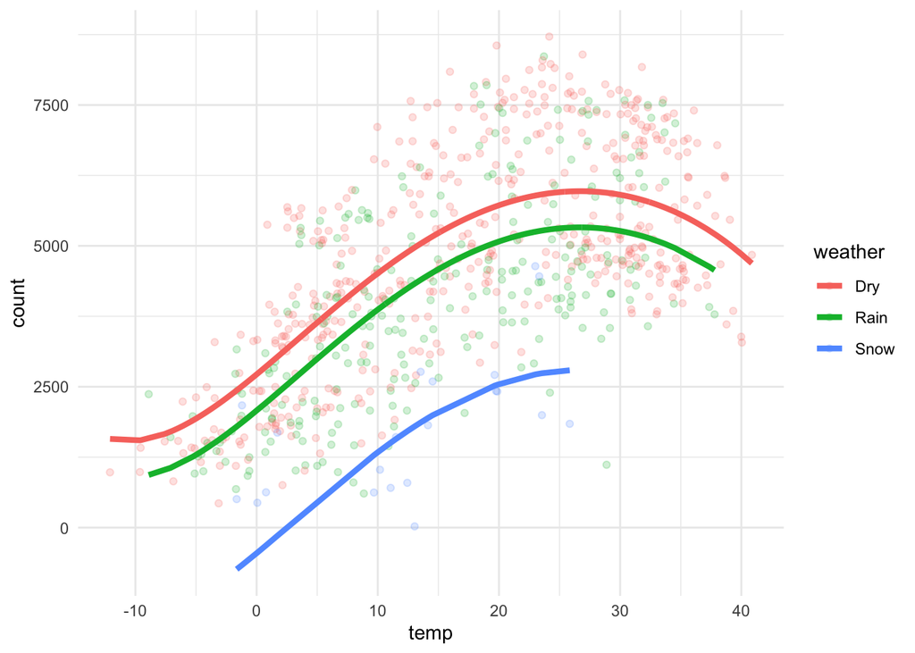

```r
model <- bikes %>%
  filter(train_id == "train") %>%
  lm(count ~ poly(temp, 5) + weather, data = .)

bikes %>%
  mutate(score_pred = predict(model, newdata = .)) %>%
  ggplot(aes(temp, count)) +
    geom_point(aes(color = weather), alpha = 0.2) +
    geom_line(aes(y = score_pred, color = weather), size = 1.5)
```

Unsurprisingly, rain decreases usage a bit and snow decreases significantly. Under the hood, R is created two indicator variables, one an indicator for Rain and the other for Snow. The details are important if you want to do statistical inferences, but the visualization is sufficent for understanding the concept from a predictive perspective.

## Linear Models with Matrices

### Matrix Formulation

We have been working with multivariate linear models with several variables, though I have only ever written the formal equation in the case where there are two explanatory variables. In general, multivariate regression represents the following model:

$$y_i = x_{1,i} \beta_1 + x_{2,i} \beta_2 + \cdots + x_{1,p} \beta_p + \epsilon_i$$

For simplicity, we won’t include an explicit intercept term in the model. If we want one, we will just make the first variable $x_{1,i}$ equal to one for every value of i.

The statistical estimation problem is to estimate the p components of the multivariate vector beta.

Using the notation of matrix multiplication, we can write the linear model simultaneously for all observations:

$$\left(\begin{array}{c}y_1\\ y_2\\ \vdots\\ y_n\end{array}\right) =
\left(\begin{array}{cccc}x_{1,1}&x_{2,1}&\cdots&x_{p,1}\\
x_{1,2}&\ddots&&x_{p,2}\\
\vdots&&\ddots&\vdots\\
x_{1,n}&x_{2,n}&\cdots&x_{p,n}\\\end{array}\right)
\left(\begin{array}{c}\beta_1\\ \beta_2\\ \vdots\\ \beta_p\end{array}\right) +
\left(\begin{array}{c}\epsilon_1\\ \epsilon_2\\ \vdots\\ \epsilon_n\end{array}\right)$$

Which can be compactly written as:

$$y = X \beta + \epsilon$$

The matrix X is known as the **design matrix** or **model matrix**.

## Fitting Linear Models with Matricies

Note that the bikes data, like every other data set we have used, is not a matrix. It is something that R calls a **data frame**:

```r
class(bikes)
```

```
## [1] "spec_tbl_df" "tbl_df"      "tbl"         "data.frame"
```

While both matrices and data frames have data organized in rows and columns, matrices force all of the data to be numeric (its actually more complicated than this in R, but just go along with it for now). A data frame on the other hand can have different variable types in each column.

The formula interface to `lm` is incredibly useful when using categorical variables or when processing numeric variables by special functions such as `poly`. The functions `model.frame` and `model.matrix` allow us to compute the model matrix from the formula interface. In fact, the `lm` function calls these to convert our inputs into a model matrix. The output of this is then passed to `lm.fit`. It will also, by default, include an intercept term for us. Here we use it to build a model matrix as before:

```r
mf <- model.frame(count ~ temp +  humidity , data = bikes)
mt <- terms(mf)
y <- model.response(mf)
X <- model.matrix(mt, mf)

head(X)
```

```
##   (Intercept)      temp humidity
## 1           1  6.715022 0.805833
## 2           1  7.989548 0.696087
## 3           1 -3.039976 0.437273
## 4           1 -2.800000 0.590435
## 5           1 -1.020838 0.436957
## 6           1 -2.513032 0.518261
```

Notice that the intercept has been added for us. What is nice about this formulation is that we can use commands like `poly` and categorical variables and have R take care of all the hard work for us:

```r
mf <- model.frame(count ~ temp + weather, data = bikes)
mt <- attr(mf, "terms")
y <- model.response(mf)
X <- model.matrix(mt, mf)

head(X)
```

```
##   (Intercept)      temp weatherRain weatherSnow
## 1           1  6.715022           1           0
## 2           1  7.989548           1           0
## 3           1 -3.039976           0           0
## 4           1 -2.800000           0           0
## 5           1 -1.020838           0           0
## 6           1 -2.513032           0           0
```

We can then create a specific training set using the following syntax:

```r
X_train <- X[bikes$train_id == "train", ]
y_train <- y[bikes$train_id == "train"]
```

We will find that many of the more complex algorithms for fitting models in R require the user to produce a model matrix before passing the data to the statistical learning algorithm.

## Using lm.fit

We have seen how to use the `lm` function to quickly fit linear regression directly from data frames. Now, how do we actually fit a linear model once we have these matrices? Next class we will see how to do this directly with matrix operations. There is an intermediate function that solves the linear regression problem directly from our matrices called `lm.fit`. In fact, the `lm` function internally calls this function. As inputs, it takes just the X matrix and response y. There is a lot of diagnostic output, but we will take just the `coef` component, corresponding to the coefficients matrix:

```r
beta <- lm.fit(X_train, y_train)$coef
beta
```

```
## (Intercept)        temp weatherRain weatherSnow
##  3217.96301    91.33425  -502.97012 -2828.49363
```

We can create predicted values for the whole data set by matrix multiplying `X` with `beta`:

```r
bikes %>%
  mutate(count_pred = X %*% beta) %>%
  select(count, count_pred)
```

```
## # A tibble: 731 x 2
##    count count_pred[,1]
##    <dbl>          <dbl>
##  1   985          3328.
##  2   801          3445.
##  3  1349          2940.
##  4  1562          2962.
##  5  1600          3125.
##  6  1606          2988.
##  7  1510          2438.
##  8   959          2248.
##  9   822          2590.
## 10  1321          2666.
## # … with 721 more rows
```

Let’s verify that this gives the same output as the `lm` function:

```r
bikes %>%
  filter(train_id == "train") %>%
  lm(count ~ temp + weather, data = .) %>%
  summary()
```

```
##
## Call:
## lm(formula = count ~ temp + weather, data = .)
##
## Residuals:
##     Min      1Q  Median      3Q     Max
## -4237.7 -1175.3   -91.5   983.7  3482.9
##
## Coefficients:
##              Estimate Std. Error t value Pr(>|t|)
## (Intercept)  3217.963    131.958  24.386  < 2e-16 ***
## temp           91.334      5.678  16.085  < 2e-16 ***
## weatherRain  -502.970    144.412  -3.483 0.000546 ***
## weatherSnow -2828.494    378.287  -7.477 4.18e-13 ***
## ---
## Signif. codes:  0 '***' 0.001 '**' 0.01 '*' 0.05 '.' 0.1 ' ' 1
##
## Residual standard error: 1423 on 438 degrees of freedom
## Multiple R-squared:  0.4421, Adjusted R-squared:  0.4383
## F-statistic: 115.7 on 3 and 438 DF,  p-value: < 2.2e-16
```

And, as hoped, it does!

Generally, it is recommended to us the `lm` function directly if your goal is just to produce a linear regression model. Creating a model matrix is a useful process to know, however, as we move towards more complex learning methods.

### Direct computation (optional)

Some of you may have taken a class where you derived the analytic form of the linear regression estimator. It is sometimes shown in a linear algebra class or advanced econometrics course. We can compactly write the estimator as the following matrix product:

$$\hat{\beta} = (X^t X)^{-1} X^t y$$

And sure enough, this is the same solution given by the `lm` and `lm.fit` functions:

```r
solve(crossprod(X_train), crossprod(X_train, y_train))
```

```
##                    [,1]
## (Intercept)  3217.96301
## temp           91.33425
## weatherRain  -502.97012
## weatherSnow -2828.49363
```

We will explore the use of matrix products later in the semester when we look at PCA and spectral clustering.